# Diagonal Case

## 4.4 The output from the basic fit

The final object has many components

```r
names(demo.fit)
```

```
#>  [1] "n.chains"           "n.iter"             "n.burnin"
#>  [4] "n.thin"             "n.keep"             "n.sims"
#>  [7] "sims.array"         "sims.list"          "sims.matrix"
#> [10] "summary"            "mean"               "sd"
#> [13] "median"             "root.short"         "long.short"
#> [16] "dimension.short"    "indexes.short"      "last.values"
#> [19] "program"            "model.file"         "isDIC"
#> [22] "DICbyR"             "pD"                 "DIC"
#> [25] "model"              "parameters.to.save" "plots"
#> [28] "runTime"            "report"             "data"
```

The *plots* sub-object contains many plots:

```r
names(demo.fit$plots)
```

```
#> [1] "init.plot"         "fit.plot"          "logitP.plot"
#> [4] "acf.Utot.plot"     "post.UNtot.plot"   "gof.plot"
#> [7] "trace.logitP.plot" "trace.logU.plot"
```

In particular, it contains plots of the initial spline fit (*init.plot*), the final fitted spline (*fit.plot*), the estimated capture probabilities (on the logit scale) (*logitP.plot*), plots of the distribution of the posterior sample for the total unmarked and marked fish (*post.UNtot.plot*) and model diagnostic plots (goodness of fit (*gof.plot*), trace (*trace…plot*), and autocorrelation plots (*act.Utot.plot*).

These plots are all created using the $ggplot2$ packages, so the user can modify the plot (e.g. change titles etc).

The $BTSPAS$ program also creates a report, which includes information about the data used in the fitting, the pooled- and stratified-Petersen estimates, a test for pooling, and summaries of the posterior. Only the first few lines are shown below:

```r
head(demo.fit$report)
```

```
#> [1] "Time Stratified Petersen with Diagonal recaptures and error in smoothed U -  Sun Oct 24 15:37:06 2021"
#> [2] "Version: 2021-11-02 "
#> [3] ""
#> [4] ""
#> [5] ""
#> [6] " Junction City 2003 Chinook  Results "
```

Here is the fitted spline curve to the number of unmarked fish available in each recovery sample

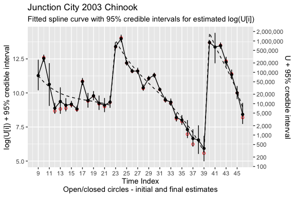

Fitted spline curve

```r
demo.fit$plots$fit.plot
```

The jump in the spline when hatchery fish are released is evident. The actual number of unmarked fish is allowed to vary around the spline as shown below.

The distribution of the posterior sample for the total number unmarked and total abundance is available:

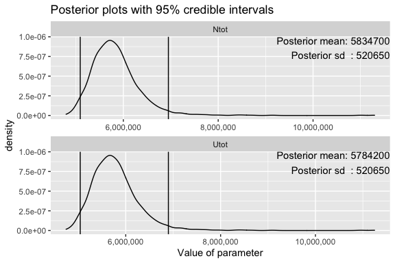

Distribution of posterior samples

```r
demo.fit$plots$post.UNtot.plot
```

A plot of the $logit(P)$ is

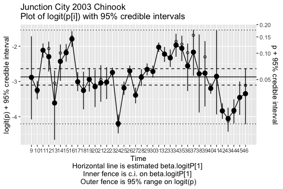

Estimates of logit(p)

```r
demo.fit$plots$logitP.plot
```

A summary of the posterior for each parameter is also available. In particular, here are the summary statistics on the posterior sample for the total number unmarked and total abundance:

```r
demo.fit$summary[ row.names(demo.fit$summary) %in% c("Ntot","Utot"),]
```

```
#>         mean       sd    2.5%     25%     50%     75%   97.5%     Rhat n.eff
#> Ntot 5834690 520650.8 5091090 5498342 5765732 6066297 6949601 1.004049   500
#> Utot 5784225 520650.8 5040625 5447877 5715267 6015832 6899136 1.004053   500
```

This also includes the Rubin-Brooks-Gelman statistic ($Rhat$) on mixing of the chains and the effective sample size of the posterior (after accounting for autocorrelation).

The estimated total abundance from $BTSPAS$ is 5,834,690 (SD 520,651 ) fish.

Samples from the posterior are also included in the *sims.matrix*, *sims.array* and *sims.list* elements of the results object.

It is always important to do model assessment before accepting the results from the model fit. Please contact me for details on how to interpret the goodness of fit, trace, and autocorrelation plots.